# Personal Loan Campaign - Problem Statement

Personal Loan Campaign - Problem Statement

Description Background and Context

AllLife Bank is a US bank that has a growing customer base. The majority of these customers are liability customers (depositors) with varying sizes of deposits. The number of customers who are also borrowers (asset customers) is quite small, and the bank is interested in expanding this base rapidly to bring in more loan business and in the process, earn more through the interest on loans. In particular, the management wants to explore ways of converting its liability customers to personal loan customers (while retaining them as depositors).

A campaign that the bank ran last year for liability customers showed a healthy conversion rate of over 9% success. This has encouraged the retail marketing department to devise campaigns with better target marketing to increase the success ratio.

You as a Data scientist at AllLife bank have to build a model that will help the marketing department to identify the potential customers who have a higher probability of purchasing the loan.

Objective

To predict whether a liability customer will buy a personal loan or not. Which variables are most significant. Which segment of customers should be targeted more. Data Dictionary

- ID: Customer ID
- Age: Customer’s age in completed years
- Experience: #years of professional experience
- Income: Annual income of the customer (in thousand dollars)
- ZIP Code: Home Address ZIP code.
- Family: the Family size of the customer
- CCAvg: Average spending on credit cards per month (in thousand dollars)
- Education: Education Level. 1: Undergrad; 2: Graduate;3: Advanced/Professional
- Mortgage: Value of house mortgage if any. (in thousand dollars)
- Personal_Loan: Did this customer accept the personal loan offered in the last campaign?
- Securities_Account: Does the customer have securities account with the bank?
- CD_Account: Does the customer have a certificate of deposit (CD) account with the bank?
- Online: Do customers use internet banking facilities?
- CreditCard: Does the customer use a credit card issued by any other Bank (excluding All life Bank)?

Best Practices for Notebook :

The notebook should be well-documented, with inline comments explaining the functionality of code and markdown cells containing comments on the observations and insights. The notebook should be run from start to finish in a sequential manner before submission. It is preferable to remove all warnings and errors before submission. The notebook should be submitted as an Pdf file

Perform an Exploratory Data Analysis on the data

Model building - Logistic Regression

Build the logistic regression model.

Build the model and comment on the model performance. - Identify the key variables that have a strong relationship with the dependent variable - Comment on model performance

```python
# Importing the libraries
import numpy as np
import pandas as pd
import matplotlib.pyplot as plt
%matplotlib inline
import seaborn as sns

from sklearn import tree
from sklearn.tree import DecisionTreeClassifier

from sklearn.linear_model import LogisticRegression
from sklearn.datasets import make_classification

from sklearn.model_selection import train_test_split
from sklearn import metrics
```

```python
 #loading the dataset
df = pd.read_csv('Loan_Modelling.csv')
df.head(5000)
```

|  | ID | Age | Experience | Income | ZIPCode | Family | CCAvg | Education | Mortgage | Personal_Loan | Securities_Account | CD_Account | Online | CreditCard |
| --- | --- | --- | --- | --- | --- | --- | --- | --- | --- | --- | --- | --- | --- | --- |
| 0 | 1 | 25 | 1 | 49 | 91107 | 4 | 1.6 | 1 | 0 | 0 | 1 | 0 | 0 | 0 |
| 1 | 2 | 45 | 19 | 34 | 90089 | 3 | 1.5 | 1 | 0 | 0 | 1 | 0 | 0 | 0 |
| 2 | 3 | 39 | 15 | 11 | 94720 | 1 | 1.0 | 1 | 0 | 0 | 0 | 0 | 0 | 0 |
| 3 | 4 | 35 | 9 | 100 | 94112 | 1 | 2.7 | 2 | 0 | 0 | 0 | 0 | 0 | 0 |
| 4 | 5 | 35 | 8 | 45 | 91330 | 4 | 1.0 | 2 | 0 | 0 | 0 | 0 | 0 | 1 |
| ... | ... | ... | ... | ... | ... | ... | ... | ... | ... | ... | ... | ... | ... | ... |
| 4995 | 4996 | 29 | 3 | 40 | 92697 | 1 | 1.9 | 3 | 0 | 0 | 0 | 0 | 1 | 0 |
| 4996 | 4997 | 30 | 4 | 15 | 92037 | 4 | 0.4 | 1 | 85 | 0 | 0 | 0 | 1 | 0 |
| 4997 | 4998 | 63 | 39 | 24 | 93023 | 2 | 0.3 | 3 | 0 | 0 | 0 | 0 | 0 | 0 |
| 4998 | 4999 | 65 | 40 | 49 | 90034 | 3 | 0.5 | 2 | 0 | 0 | 0 | 0 | 1 | 0 |
| 4999 | 5000 | 28 | 4 | 83 | 92612 | 3 | 0.8 | 1 | 0 | 0 | 0 | 0 | 1 | 1 |

5000 rows × 14 columns

```python
df.columns
```

```
Index(['ID', 'Age', 'Experience', 'Income', 'ZIPCode', 'Family', 'CCAvg',
       'Education', 'Mortgage', 'Personal_Loan', 'Securities_Account',
       'CD_Account', 'Online', 'CreditCard'],
      dtype='object')
```

```python
df.info()
```

```
<class 'pandas.core.frame.DataFrame'>
RangeIndex: 5000 entries, 0 to 4999
Data columns (total 14 columns):
 #   Column              Non-Null Count  Dtype
---  ------              --------------  -----
 0   ID                  5000 non-null   int64
 1   Age                 5000 non-null   int64
 2   Experience          5000 non-null   int64
 3   Income              5000 non-null   int64
 4   ZIPCode             5000 non-null   int64
 5   Family              5000 non-null   int64
 6   CCAvg               5000 non-null   float64
 7   Education           5000 non-null   int64
 8   Mortgage            5000 non-null   int64
 9   Personal_Loan       5000 non-null   int64
 10  Securities_Account  5000 non-null   int64
 11  CD_Account          5000 non-null   int64
 12  Online              5000 non-null   int64
 13  CreditCard          5000 non-null   int64
dtypes: float64(1), int64(13)
memory usage: 547.0 KB
```

```python
#Check the shape of dataframe
df.shape
```

```
(5000, 14)
```

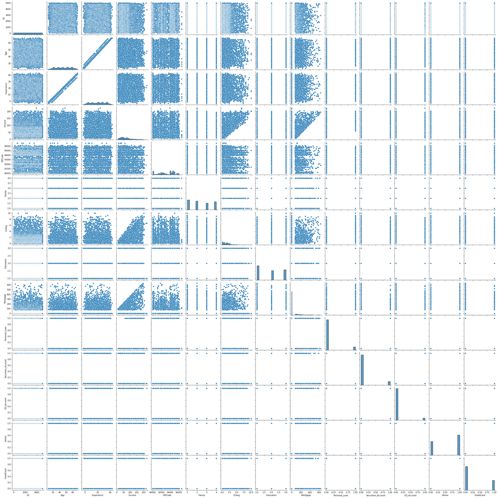

```python
#Plot the scatterplots for features
sns.pairplot(df)
plt.show()
```

```python
df[df['Experience'] < 0]['Experience'].count()    #records with negative experience
```

```
52
```

```python
#clean the negative variable

dfExp = df.loc[df['Experience'] >0]
negExp = df.Experience < 0
column_name = 'Experience'
# getting the customer ID who has negative experience
mylist = df.loc[negExp]['ID'].tolist()
# there are 52 records with negative experience
negExp.value_counts()
```

```
False    4948
True       52
Name: Experience, dtype: int64
```

```python
for id in mylist:
    age = df.loc[np.where(df['ID']==id)]["Age"].tolist()[0] #For the record with the ID, get the value of Age column

    #For the record with the ID, get the value of Education column
    education = df.loc[np.where(df['ID']==id)]["Education"].tolist()[0]
    #Filter the records matching the above criteria from the data frame which
    #has records with positive experience and take the median
    df_filtered = dfExp[(dfExp.Age == age) & (dfExp.Education == education)]
    exp = df_filtered['Experience'].median()
    df.loc[df.loc[np.where(df['ID']==id)].index, 'Experience'] = exp
```

```python
# checking if there are records with negative experience
df[df['Experience'] < 0]['Experience'].count()
```

```
0
```

```python
df.describe() ## Viewing the data statistics
```

|  | ID | Age | Experience | Income | ZIPCode | Family | CCAvg | Education | Mortgage | Personal_Loan | Securities_Account | CD_Account | Online | CreditCard |
| --- | --- | --- | --- | --- | --- | --- | --- | --- | --- | --- | --- | --- | --- | --- |
| count | 5000.000000 | 5000.000000 | 4971.000000 | 5000.000000 | 5000.000000 | 5000.000000 | 5000.000000 | 5000.000000 | 5000.000000 | 5000.000000 | 5000.000000 | 5000.00000 | 5000.000000 | 5000.000000 |
| mean | 2500.500000 | 45.338400 | 20.243211 | 73.774200 | 93169.257000 | 2.396400 | 1.937938 | 1.881000 | 56.498800 | 0.096000 | 0.104400 | 0.06040 | 0.596800 | 0.294000 |
| std | 1443.520003 | 11.463166 | 11.359189 | 46.033729 | 1759.455086 | 1.147663 | 1.747659 | 0.839869 | 101.713802 | 0.294621 | 0.305809 | 0.23825 | 0.490589 | 0.455637 |
| min | 1.000000 | 23.000000 | 0.000000 | 8.000000 | 90005.000000 | 1.000000 | 0.000000 | 1.000000 | 0.000000 | 0.000000 | 0.000000 | 0.00000 | 0.000000 | 0.000000 |
| 25% | 1250.750000 | 35.000000 | 10.000000 | 39.000000 | 91911.000000 | 1.000000 | 0.700000 | 1.000000 | 0.000000 | 0.000000 | 0.000000 | 0.00000 | 0.000000 | 0.000000 |
| 50% | 2500.500000 | 45.000000 | 20.000000 | 64.000000 | 93437.000000 | 2.000000 | 1.500000 | 2.000000 | 0.000000 | 0.000000 | 0.000000 | 0.00000 | 1.000000 | 0.000000 |
| 75% | 3750.250000 | 55.000000 | 30.000000 | 98.000000 | 94608.000000 | 3.000000 | 2.500000 | 3.000000 | 101.000000 | 0.000000 | 0.000000 | 0.00000 | 1.000000 | 1.000000 |
| max | 5000.000000 | 67.000000 | 43.000000 | 224.000000 | 96651.000000 | 4.000000 | 10.000000 | 3.000000 | 635.000000 | 1.000000 | 1.000000 | 1.00000 | 1.000000 | 1.000000 |

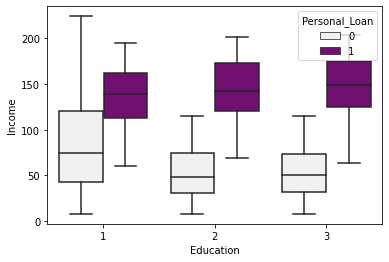

```python
sns.boxplot(x='Education',y='Income',hue='Personal_Loan',data=df,color='purple')
```

Observation : It seems the customers whose education level is 1 is having more income. However customers who has taken the personal loan have the same income levels

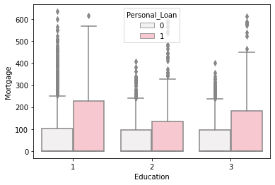

```python
sns.boxplot(x="Education", y='Mortgage', hue="Personal_Loan", data=df,color='pink')
```

From the above chart it seems that customer who do not have personal loan and customer who has personal loan have high mortgage

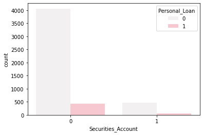

```python
sns.countplot(x="Securities_Account", data=df,hue="Personal_Loan",color='pink')
```

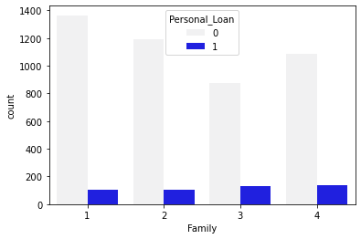

```python
sns.countplot(x='Family',data=df,hue='Personal_Loan',color='blue')
```

Observation: Family size does not have any impact in personal loan. But it seems families with size of 3 are more likely to take loan. When considering future campaign this might be good association.

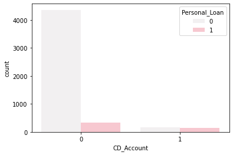

```python
sns.countplot(x='CD_Account',data=df,hue='Personal_Loan',color='pink')
```

```
Credit card spending of Non-Loan customers:  1400.0
Credit card spending of Loan customers    :  3800.0
```

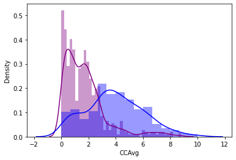

```python
sns.distplot( df[df.Personal_Loan == 0]['CCAvg'], color = 'purple')
sns.distplot( df[df.Personal_Loan == 1]['CCAvg'], color = 'blue')


print('Credit card spending of Non-Loan customers: ',df[df.Personal_Loan == 0]['CCAvg'].median()*1000)
print('Credit card spending of Loan customers    : ', df[df.Personal_Loan == 1]['CCAvg'].median()*1000)
```

Observation: The graph show persons who have personal loan have a higher credit card average. Average credit card spending with a median of 3800 dollar indicates a higher probability of personal loan. Lower credit card spending with a median of 1400 dollars is less likely to take a loan. This could be useful information.

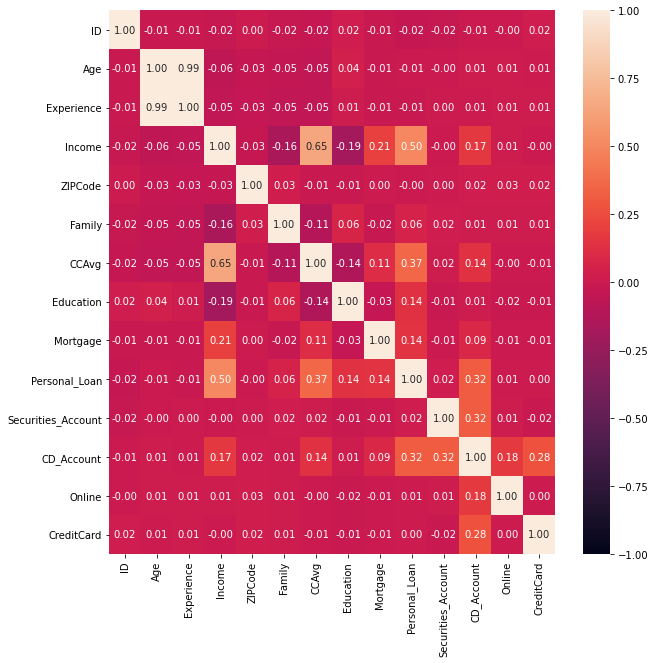

```python
##Plot the correlation heatmap
plt.figure(figsize=(10, 10))
sns.heatmap(data=df.corr(), annot=True, vmin=-1, vmax=1, fmt=".2f")
plt.show()
```

# Decision tree

```python
#Applying models
#Split data into train and test

from sklearn.model_selection import train_test_split
train_set, test_set = train_test_split(df.drop(['ID','Experience'], axis=1), test_size=0.3 , random_state=100)

train_labels = train_set.pop('Personal_Loan')
test_labels = test_set.pop('Personal_Loan')
```

```python
#Decision tree classifier

dt_model=DecisionTreeClassifier(criterion = 'entropy',max_depth=3)
dt_model.fit(train_set, train_labels)

dt_model.score(test_set , test_labels)
```

```
0.9773333333333334
```

```python
y_predict = dt_model.predict(test_set)
y_predict[:5]
```

```
array([0, 0, 0, 0, 0], dtype=int64)
```

```python
test_set.head(5)
```

|  | Age | Income | ZIPCode | Family | CCAvg | Education | Mortgage | Securities_Account | CD_Account | Online | CreditCard |
| --- | --- | --- | --- | --- | --- | --- | --- | --- | --- | --- | --- |
| 789 | 29 | 31 | 92126 | 4 | 0.3 | 2 | 0 | 0 | 0 | 1 | 0 |
| 2507 | 59 | 60 | 90048 | 4 | 2.1 | 1 | 234 | 0 | 0 | 1 | 1 |
| 2376 | 58 | 23 | 91768 | 3 | 0.2 | 1 | 0 | 0 | 0 | 0 | 0 |
| 1378 | 54 | 34 | 93305 | 4 | 0.1 | 3 | 0 | 0 | 0 | 1 | 0 |
| 598 | 56 | 11 | 92374 | 2 | 0.2 | 3 | 90 | 0 | 0 | 0 | 0 |

# Logistic Regression

```python
from sklearn.model_selection import train_test_split
x_train,x_test,y_train,y_test = train_test_split(x,y,random_state=1)
```

[output not shown]

[output not shown]

```python
x_train.shape
```

```
(75, 1)
```

```python
log_reg = LogisticRegression()
log_reg.fit(x_train,y_train)
```

```
LogisticRegression()
```

```python
y_red=log_reg.predict(x_test)
y_red
```

```
array([1, 0, 0, 1, 1, 1, 0, 1, 1, 1, 0, 1, 1, 1, 1, 1, 0, 1, 1, 0, 0, 0,
       0, 1, 1])
```

```python
from sklearn.metrics import confusion_matrix
confusion_matrix(y_test,y_red)
```

```
array([[ 9,  1],
       [ 0, 15]], dtype=int64)
```

```python
log_reg_score=log_reg.score(x_test,y_test)
print(log_reg_score)
```

```
0.96
```